# Rで微分偏微分を行う

UPDATE: 2022-08-27 13:09:58

# はじめに

このノートではRを使った微分、偏微分の方法をまとめておく。

## 微分

### 1変数の1階微分

$h$が十分小さいとき、1変数の微分は定義によると下記のように表現できる。

$$f^{\prime}(x)= \frac{f(x+h) - f(x)}{h}$$

Rで計算するには、先程の式をそのまま利用すれば良い。ここでは、$f(x)=2x^3$の$x=3$を計算してみる。

```r
h <- 0.001

f <- function(x){
  return(2*x^3)
}

x <- 3

d <- function(x){
  res <- (f(x + h) - f(x)) / h
  return(res)
}

d(x)
```

```
## [1] 54.018
```

この結果をRの組み込み関数を使って検証すると、近似的な解が得られていることがわかる。

```r
d <- D(expression(2*x^3), 'x')
# print(eval(expression(d)))
eval(d)
```

```
## [1] 54
```

```r
# library(numDeriv)
# d <- genD(func = f, x)
# d$f0
```

### 1変数の2階微分

$h$が十分小さいとき、1変数の2階微分は定義によると下記のように表現できる。

$$f^{(2)}(x)= \frac{f(x+2h) - 2f(x+h) + f(x)}{h^{2}}$$

Rで計算するには、1階微分同様にそのまま利用すれば良い。ここでは、$f(x)=2x^3$の$x=3$を計算してみる。

```r
h <- 0.001

f <- function(x){
  return(2*x^3)
}

x <- 3

d2 <- function(x){
  res <- (f(x + 2*h) - 2*f(x + h) +  f(x)) / h^2
  return(res)
}

d2(x)
```

```
## [1] 36.012
```

さきほど同様に、この結果をRの組み込み関数を使って検証すると、近似的な解が得られていることがわかる。2階微分は`D(D(f))`とすれば良いらしい。

```r
d2 <- D(D(expression(2*x^3), 'x'), 'x')
# print(eval(expression(d)))
eval(d2)
```

```
## [1] 36
```

## 偏微分

$h$が十分小さいとき、$y$、$x$という順に偏微分する場合、定義によると下記のように表現できる。

$$\frac{ \partial f }{ \partial y \partial x } = \frac{f(x+h, y+h) - f(x,
y+h)-f(x+h, y) + f(x, y)}{h^{2}}$$

Rで計算するには、これまでと同じようにそのまま利用すれば良い。ここでは、$f(x,y)=x^2 * y^3$の$x=3, y=1$を計算してみる。

```r
h <- 0.01

f <- function(x, y){
  return(x^2 * y^3)
}

x <- 3
y <- 1

pd <- function(x, y){
  res <- (f(x + h, y + h) - f(x, y + h) - f(x + h, y) + f(x, y)) / h^2
  return(res)
}

pd(x, y)
```

```
## [1] 18.2109
```

さきほど同様に、この結果をRの組み込み関数を使って検証すると、近似的な解が得られている。偏微分は`D(D(f, y),x)`とすれば良いらしい。

```r
pd <- D(D(expression(x^2 * y^3), 'y'), 'x')
# print(eval(expression(d)))
eval(pd)
```

```
## [1] 18
```

先程の2変数関数を可視化しておく。見えにくいが、$x=3, y=1$の位置でポイントを打ち込んでいる。

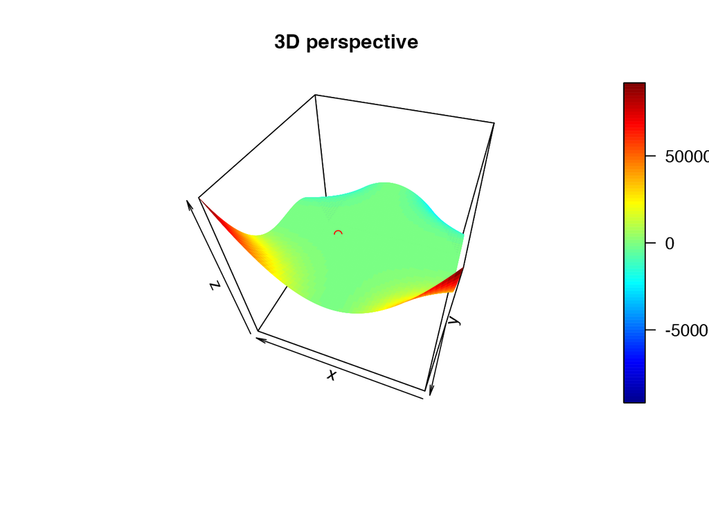

```r
library(plot3D)
y <- x <- seq(-10, 10, length=60)
f <- function(x, y) x^2 * y^3
z <- outer(x, y, f)

persp3D(
  x = x,
  y = y,
  z = z,
  color.palette = heat.colors,
  phi = 45,
  theta = 200,
  main = "3D perspective")
points3D(x = 3, y = 1, z = f(3, 1),
         col = "red", size = 10,
         add = T)
```